# R Notebook- Analysis and prediction on NASA KC1

Resource • NASA KC1

Setup : Rtool and Rstudio

# **Analysis**

## Finding 1

### Load data

```r
  library("tidyverse")
data <- read_csv("KC1_product_module_metrics.csv")
```

### view data

```r
data
```

| MODULE | LOC_BLANK | BRANCH_COUNT | LOC_CODE_AND_COMMENT | LOC_COMMENTS | CYCLOMATIC_COMPLEXITY | DESIGN_COMPLEXITY | ERROR_COUNT | ERROR_DENSITY | ESSENTIAL_COMPLEXITY | LOC_EXECUTABLE | HALSTEAD_CONTENT | HALSTEAD_DIFFICULTY | HALSTEAD_EFFORT | HALSTEAD_ERROR_EST | HALSTEAD_LENGTH | HALSTEAD_LEVEL | HALSTEAD_PROG_TIME | HALSTEAD_VOLUME | NUM_OPERANDS | NUM_OPERATORS | NUM_UNIQUE_OPERANDS | NUM_UNIQUE_OPERATORS | ERROR_REPORT_IN_1_YR | ERROR_REPORT_IN_6_MON | ERROR_REPORT_IN_2_YRS | LOC_TOTAL | X28 |
| --- | --- | --- | --- | --- | --- | --- | --- | --- | --- | --- | --- | --- | --- | --- | --- | --- | --- | --- | --- | --- | --- | --- | --- | --- | --- | --- | --- |
| 22825 | 0 | 1 | 0 | 0 | 1 | 1 | NA | NA | 1 | 3 | 11.58 | 2.67 | 82.35 | 0.01 | 11 | 0.38 | 4.57 | 30.88 | 4 | 7 | 3 | 4 | NA | NA | NA | 5 | NA |
| 22826 | 0 | 1 | 0 | 0 | 1 | 1 | NA | NA | 1 | 1 | 0.00 | 0.00 | 0.00 | 0.00 | 1 | 0.00 | 0.00 | 0.00 | 0 | 1 | 0 | 1 | NA | NA | NA | 3 | NA |
| 22827 | 0 | 1 | 0 | 0 | 1 | 1 | NA | NA | 1 | 1 | 0.00 | 0.00 | 0.00 | 0.00 | 1 | 0.00 | 0.00 | 0.00 | 0 | 1 | 0 | 1 | NA | NA | NA | 3 | NA |
| 22828 | 0 | 1 | 0 | 0 | 1 | 1 | NA | NA | 1 | 1 | 0.00 | 0.00 | 0.00 | 0.00 | 1 | 0.00 | 0.00 | 0.00 | 0 | 1 | 0 | 1 | NA | NA | NA | 3 | NA |
| 22829 | 2 | 1 | 0 | 0 | 1 | 1 | NA | NA | 1 | 8 | 18.03 | 3.50 | 220.91 | 0.02 | 19 | 0.29 | 12.27 | 63.12 | 7 | 12 | 5 | 5 | NA | NA | NA | 12 | NA |
| 22830 | 0 | 1 | 0 | 0 | 1 | 1 | NA | NA | 1 | 3 | 11.58 | 2.67 | 82.35 | 0.01 | 11 | 0.38 | 4.57 | 30.88 | 4 | 7 | 3 | 4 | NA | NA | NA | 5 | NA |
| 22831 | 0 | 1 | 0 | 0 | 1 | 1 | NA | NA | 1 | 1 | 0.00 | 0.00 | 0.00 | 0.00 | 1 | 0.00 | 0.00 | 0.00 | 0 | 1 | 0 | 1 | NA | NA | NA | 3 | NA |
| 22832 | 0 | 1 | 0 | 0 | 1 | 1 | NA | NA | 1 | 1 | 0.00 | 0.00 | 0.00 | 0.00 | 1 | 0.00 | 0.00 | 0.00 | 0 | 1 | 0 | 1 | NA | NA | NA | 3 | NA |
| 22833 | 0 | 1 | 0 | 0 | 1 | 1 | NA | NA | 1 | 1 | 0.00 | 0.00 | 0.00 | 0.00 | 1 | 0.00 | 0.00 | 0.00 | 0 | 1 | 0 | 1 | NA | NA | NA | 3 | NA |
| 22834 | 2 | 1 | 0 | 0 | 1 | 1 | NA | NA | 1 | 9 | 29.44 | 3.75 | 414.05 | 0.04 | 29 | 0.27 | 23.00 | 110.41 | 10 | 19 | 8 | 6 | NA | NA | NA | 13 | NA |

[output cut: 990 more lines]

### Cleaning data

```r
data[is.na(data)] = 0
data
```

| MODULE | LOC_BLANK | BRANCH_COUNT | LOC_CODE_AND_COMMENT | LOC_COMMENTS | CYCLOMATIC_COMPLEXITY | DESIGN_COMPLEXITY | ERROR_COUNT | ERROR_DENSITY | ESSENTIAL_COMPLEXITY | LOC_EXECUTABLE | HALSTEAD_CONTENT | HALSTEAD_DIFFICULTY | HALSTEAD_EFFORT | HALSTEAD_ERROR_EST | HALSTEAD_LENGTH | HALSTEAD_LEVEL | HALSTEAD_PROG_TIME | HALSTEAD_VOLUME | NUM_OPERANDS | NUM_OPERATORS | NUM_UNIQUE_OPERANDS | NUM_UNIQUE_OPERATORS | ERROR_REPORT_IN_1_YR | ERROR_REPORT_IN_6_MON | ERROR_REPORT_IN_2_YRS | LOC_TOTAL | X28 |
| --- | --- | --- | --- | --- | --- | --- | --- | --- | --- | --- | --- | --- | --- | --- | --- | --- | --- | --- | --- | --- | --- | --- | --- | --- | --- | --- | --- |
| 22825 | 0 | 1 | 0 | 0 | 1 | 1 | 0 | 0.000000 | 1 | 3 | 11.58 | 2.67 | 82.35 | 0.01 | 11 | 0.38 | 4.57 | 30.88 | 4 | 7 | 3 | 4 | 0 | 0 | 0 | 5 | FALSE |
| 22826 | 0 | 1 | 0 | 0 | 1 | 1 | 0 | 0.000000 | 1 | 1 | 0.00 | 0.00 | 0.00 | 0.00 | 1 | 0.00 | 0.00 | 0.00 | 0 | 1 | 0 | 1 | 0 | 0 | 0 | 3 | FALSE |
| 22827 | 0 | 1 | 0 | 0 | 1 | 1 | 0 | 0.000000 | 1 | 1 | 0.00 | 0.00 | 0.00 | 0.00 | 1 | 0.00 | 0.00 | 0.00 | 0 | 1 | 0 | 1 | 0 | 0 | 0 | 3 | FALSE |
| 22828 | 0 | 1 | 0 | 0 | 1 | 1 | 0 | 0.000000 | 1 | 1 | 0.00 | 0.00 | 0.00 | 0.00 | 1 | 0.00 | 0.00 | 0.00 | 0 | 1 | 0 | 1 | 0 | 0 | 0 | 3 | FALSE |
| 22829 | 2 | 1 | 0 | 0 | 1 | 1 | 0 | 0.000000 | 1 | 8 | 18.03 | 3.50 | 220.91 | 0.02 | 19 | 0.29 | 12.27 | 63.12 | 7 | 12 | 5 | 5 | 0 | 0 | 0 | 12 | FALSE |
| 22830 | 0 | 1 | 0 | 0 | 1 | 1 | 0 | 0.000000 | 1 | 3 | 11.58 | 2.67 | 82.35 | 0.01 | 11 | 0.38 | 4.57 | 30.88 | 4 | 7 | 3 | 4 | 0 | 0 | 0 | 5 | FALSE |
| 22831 | 0 | 1 | 0 | 0 | 1 | 1 | 0 | 0.000000 | 1 | 1 | 0.00 | 0.00 | 0.00 | 0.00 | 1 | 0.00 | 0.00 | 0.00 | 0 | 1 | 0 | 1 | 0 | 0 | 0 | 3 | FALSE |
| 22832 | 0 | 1 | 0 | 0 | 1 | 1 | 0 | 0.000000 | 1 | 1 | 0.00 | 0.00 | 0.00 | 0.00 | 1 | 0.00 | 0.00 | 0.00 | 0 | 1 | 0 | 1 | 0 | 0 | 0 | 3 | FALSE |
| 22833 | 0 | 1 | 0 | 0 | 1 | 1 | 0 | 0.000000 | 1 | 1 | 0.00 | 0.00 | 0.00 | 0.00 | 1 | 0.00 | 0.00 | 0.00 | 0 | 1 | 0 | 1 | 0 | 0 | 0 | 3 | FALSE |
| 22834 | 2 | 1 | 0 | 0 | 1 | 1 | 0 | 0.000000 | 1 | 9 | 29.44 | 3.75 | 414.05 | 0.04 | 29 | 0.27 | 23.00 | 110.41 | 10 | 19 | 8 | 6 | 0 | 0 | 0 | 13 | FALSE |

[output cut: 990 more lines]

### Structure and data types of the data

```r
str(data)
```

```
tibble [2,107 x 28] (S3: spec_tbl_df/tbl_df/tbl/data.frame)
 $ MODULE               : num [1:2107] 22825 22826 22827 22828 22829 ...
 $ LOC_BLANK            : num [1:2107] 0 0 0 0 2 0 0 0 0 2 ...
 $ BRANCH_COUNT         : num [1:2107] 1 1 1 1 1 1 1 1 1 1 ...
 $ LOC_CODE_AND_COMMENT : num [1:2107] 0 0 0 0 0 0 0 0 0 0 ...
 $ LOC_COMMENTS         : num [1:2107] 0 0 0 0 0 0 0 0 0 0 ...
 $ CYCLOMATIC_COMPLEXITY: num [1:2107] 1 1 1 1 1 1 1 1 1 1 ...
 $ DESIGN_COMPLEXITY    : num [1:2107] 1 1 1 1 1 1 1 1 1 1 ...
 $ ERROR_COUNT          : num [1:2107] 0 0 0 0 0 0 0 0 0 0 ...
 $ ERROR_DENSITY        : num [1:2107] 0 0 0 0 0 0 0 0 0 0 ...
 $ ESSENTIAL_COMPLEXITY : num [1:2107] 1 1 1 1 1 1 1 1 1 1 ...
 $ LOC_EXECUTABLE       : num [1:2107] 3 1 1 1 8 3 1 1 1 9 ...
 $ HALSTEAD_CONTENT     : num [1:2107] 11.6 0 0 0 18 ...
 $ HALSTEAD_DIFFICULTY  : num [1:2107] 2.67 0 0 0 3.5 2.67 0 0 0 3.75 ...
 $ HALSTEAD_EFFORT      : num [1:2107] 82.3 0 0 0 220.9 ...
 $ HALSTEAD_ERROR_EST   : num [1:2107] 0.01 0 0 0 0.02 0.01 0 0 0 0.04 ...
 $ HALSTEAD_LENGTH      : num [1:2107] 11 1 1 1 19 11 1 1 1 29 ...
 $ HALSTEAD_LEVEL       : num [1:2107] 0.38 0 0 0 0.29 0.38 0 0 0 0.27 ...
 $ HALSTEAD_PROG_TIME   : num [1:2107] 4.57 0 0 0 12.27 ...
 $ HALSTEAD_VOLUME      : num [1:2107] 30.9 0 0 0 63.1 ...
 $ NUM_OPERANDS         : num [1:2107] 4 0 0 0 7 4 0 0 0 10 ...
 $ NUM_OPERATORS        : num [1:2107] 7 1 1 1 12 7 1 1 1 19 ...
 $ NUM_UNIQUE_OPERANDS  : num [1:2107] 3 0 0 0 5 3 0 0 0 8 ...
 $ NUM_UNIQUE_OPERATORS : num [1:2107] 4 1 1 1 5 4 1 1 1 6 ...
 $ ERROR_REPORT_IN_1_YR : num [1:2107] 0 0 0 0 0 0 0 0 0 0 ...
 $ ERROR_REPORT_IN_6_MON: num [1:2107] 0 0 0 0 0 0 0 0 0 0 ...
 $ ERROR_REPORT_IN_2_YRS: num [1:2107] 0 0 0 0 0 0 0 0 0 0 ...
 $ LOC_TOTAL            : num [1:2107] 5 3 3 3 12 5 3 3 3 13 ...
 $ X28                  : logi [1:2107] FALSE FALSE FALSE FALSE FALSE FALSE ...
 - attr(*, "spec")=
  .. cols(
  ..   MODULE = col_double(),
  ..   LOC_BLANK = col_double(),
  ..   BRANCH_COUNT = col_double(),
  ..   LOC_CODE_AND_COMMENT = col_double(),
  ..   LOC_COMMENTS = col_double(),
  ..   CYCLOMATIC_COMPLEXITY = col_double(),
  ..   DESIGN_COMPLEXITY = col_double(),
  ..   ERROR_COUNT = col_double(),
  ..   ERROR_DENSITY = col_double(),
  ..   ESSENTIAL_COMPLEXITY = col_double(),
  ..   LOC_EXECUTABLE = col_double(),
  ..   HALSTEAD_CONTENT = col_double(),
  ..   HALSTEAD_DIFFICULTY = col_double(),
  ..   HALSTEAD_EFFORT = col_double(),
  ..   HALSTEAD_ERROR_EST = col_double(),
  ..   HALSTEAD_LENGTH = col_double(),
  ..   HALSTEAD_LEVEL = col_double(),
  ..   HALSTEAD_PROG_TIME = col_double(),
  ..   HALSTEAD_VOLUME = col_double(),
  ..   NUM_OPERANDS = col_double(),
  ..   NUM_OPERATORS = col_double(),
  ..   NUM_UNIQUE_OPERANDS = col_double(),
  ..   NUM_UNIQUE_OPERATORS = col_double(),
  ..   ERROR_REPORT_IN_1_YR = col_double(),
  ..   ERROR_REPORT_IN_6_MON = col_double(),
  ..   ERROR_REPORT_IN_2_YRS = col_double(),
  ..   LOC_TOTAL = col_double(),
  ..   X28 = col_logical()
  .. )
```

### summary of the data

summary provides the various statistical information about the data like mean, median, min , max values.

```r
summary(data)
```

```
     MODULE        LOC_BLANK      BRANCH_COUNT    LOC_CODE_AND_COMMENT  LOC_COMMENTS     CYCLOMATIC_COMPLEXITY DESIGN_COMPLEXITY
 Min.   :22825   Min.   : 0.00   Min.   : 1.000   Min.   : 0.0000      Min.   : 0.0000   Min.   : 1.00         Min.   : 1.000
 1st Qu.:23370   1st Qu.: 0.00   1st Qu.: 1.000   1st Qu.: 0.0000      1st Qu.: 0.0000   1st Qu.: 1.00         1st Qu.: 1.000
 Median :23898   Median : 0.00   Median : 1.000   Median : 0.0000      Median : 0.0000   Median : 1.00         Median : 1.000
 Mean   :23896   Mean   : 1.76   Mean   : 4.669   Mean   : 0.1315      Mean   : 0.9454   Mean   : 2.84         Mean   : 2.548
 3rd Qu.:24425   3rd Qu.: 2.00   3rd Qu.: 5.000   3rd Qu.: 0.0000      3rd Qu.: 0.0000   3rd Qu.: 3.00         3rd Qu.: 3.000
 Max.   :24951   Max.   :58.00   Max.   :89.000   Max.   :12.0000      Max.   :44.0000   Max.   :45.00         Max.   :45.000
  ERROR_COUNT     ERROR_DENSITY     ESSENTIAL_COMPLEXITY LOC_EXECUTABLE   HALSTEAD_CONTENT HALSTEAD_DIFFICULTY HALSTEAD_EFFORT
 Min.   :0.0000   Min.   :  0.000   Min.   : 1.000       Min.   :  0.00   Min.   :  0.00   Min.   : 0.000      Min.   :     0
 1st Qu.:0.0000   1st Qu.:  0.000   1st Qu.: 1.000       1st Qu.:  0.00   1st Qu.:  5.33   1st Qu.: 1.500      1st Qu.:    12
 Median :0.0000   Median :  0.000   Median : 1.000       Median :  5.00   Median : 14.40   Median : 3.500      Median :   214
 Mean   :0.2492   Mean   :  9.321   Mean   : 1.675       Mean   : 14.54   Mean   : 21.26   Mean   : 6.777      Mean   :  5247
 3rd Qu.:0.0000   3rd Qu.:  0.000   3rd Qu.: 1.000       3rd Qu.: 17.00   3rd Qu.: 29.85   3rd Qu.: 9.230      3rd Qu.:  2278
 Max.   :7.0000   Max.   :750.000   Max.   :26.000       Max.   :262.00   Max.   :193.06   Max.   :53.750      Max.   :324804
 HALSTEAD_ERROR_EST HALSTEAD_LENGTH   HALSTEAD_LEVEL   HALSTEAD_PROG_TIME HALSTEAD_VOLUME    NUM_OPERANDS   NUM_OPERATORS
 Min.   :0.00000    Min.   :   0.00   Min.   :0.0000   Min.   :    0.00   Min.   :   0.00   Min.   :  0.0   Min.   :  0.00
 1st Qu.:0.00000    1st Qu.:   4.00   1st Qu.:0.0800   1st Qu.:    0.67   1st Qu.:   8.00   1st Qu.:  1.0   1st Qu.:  3.00
 Median :0.02000    Median :  16.00   Median :0.2000   Median :   11.89   Median :  57.06   Median :  6.0   Median : 10.00
 Mean   :0.08573    Mean   :  49.88   Mean   :0.3188   Mean   :  291.52   Mean   : 258.94   Mean   : 18.8   Mean   : 31.07
 3rd Qu.:0.09000    3rd Qu.:  58.00   3rd Qu.:0.6700   3rd Qu.:  126.58   3rd Qu.: 265.93   3rd Qu.: 22.0   3rd Qu.: 36.00
 Max.   :2.64000    Max.   :1106.00   Max.   :2.0000   Max.   :18044.64   Max.   :7918.82   Max.   :428.0   Max.   :678.00
 NUM_UNIQUE_OPERANDS NUM_UNIQUE_OPERATORS ERROR_REPORT_IN_1_YR ERROR_REPORT_IN_6_MON ERROR_REPORT_IN_2_YRS   LOC_TOTAL
 Min.   :  0.000     Min.   : 0.000       Min.   :0.0000       Min.   :0.0000        Min.   :0.00000       Min.   :  1.00
 1st Qu.:  1.000     1st Qu.: 3.000       1st Qu.:0.0000       1st Qu.:0.0000        1st Qu.:0.00000       1st Qu.:  3.00
 Median :  5.000     Median : 6.000       Median :0.0000       Median :0.0000        Median :0.00000       Median :  9.00
 Mean   :  9.545     Mean   : 7.638       Mean   :0.1229       Mean   :0.2074        Mean   :0.06597       Mean   : 20.39
 3rd Qu.: 13.000     3rd Qu.:11.000       3rd Qu.:0.0000       3rd Qu.:0.0000        3rd Qu.:0.00000       3rd Qu.: 24.00
 Max.   :120.000     Max.   :37.000       Max.   :5.0000       Max.   :8.0000        Max.   :4.00000       Max.   :288.00
    X28
 Mode :logical
 FALSE:2107
```

### Plotting Cyclomatic Complexity

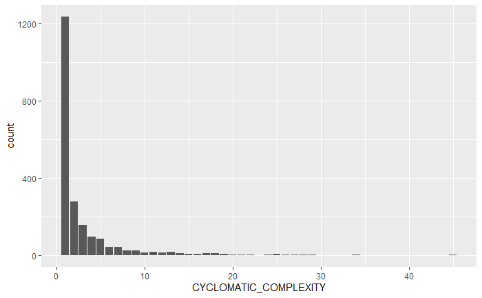

```r
ggplot(data = data) +
  geom_bar(mapping = aes(x = CYCLOMATIC_COMPLEXITY))
```

### Relation among cyclomatic Complexity and Error Count

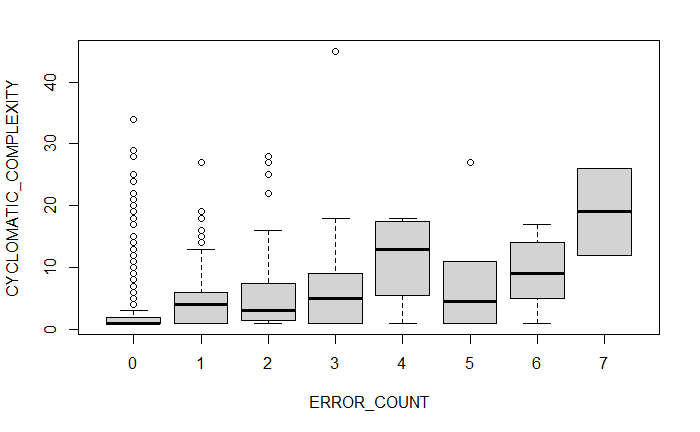

```r
boxplot(CYCLOMATIC_COMPLEXITY~ERROR_COUNT, data)
```

```r
summary(data$CYCLOMATIC_COMPLEXITY)
```

```
   Min. 1st Qu.  Median    Mean 3rd Qu.    Max.
   1.00    1.00    1.00    2.84    3.00   45.00
```

```r
summary(data$ERROR_COUNT)
```

```
   Min. 1st Qu.  Median    Mean 3rd Qu.    Max.
 0.0000  0.0000  0.0000  0.2492  0.0000  7.0000
```

### Analysis by filtering the CC value

```r
cc_restricted <- data %>%
  filter(CYCLOMATIC_COMPLEXITY <= 45)
```

Plot

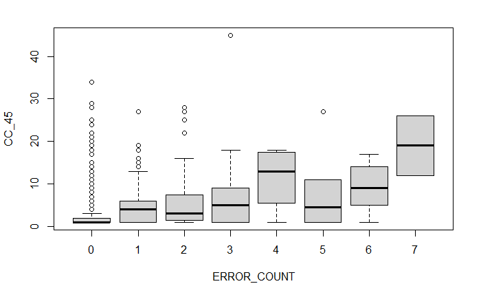

```r
 boxplot(CYCLOMATIC_COMPLEXITY~ERROR_COUNT, ylab="CC_45",cc_restricted)
```

```r
summary(cc_restricted$CYCLOMATIC_COMPLEXITY)
```

```
   Min. 1st Qu.  Median    Mean 3rd Qu.    Max.
   1.00    1.00    1.00    2.84    3.00   45.00
```

```r
summary(cc_restricted$ERROR_COUNT)
```

```
   Min. 1st Qu.  Median    Mean 3rd Qu.    Max.
 0.0000  0.0000  0.0000  0.2492  0.0000  7.0000
```

for CC < 16

```r
cc_restricted <- data %>%
  filter(CYCLOMATIC_COMPLEXITY < 16)
```

Plot

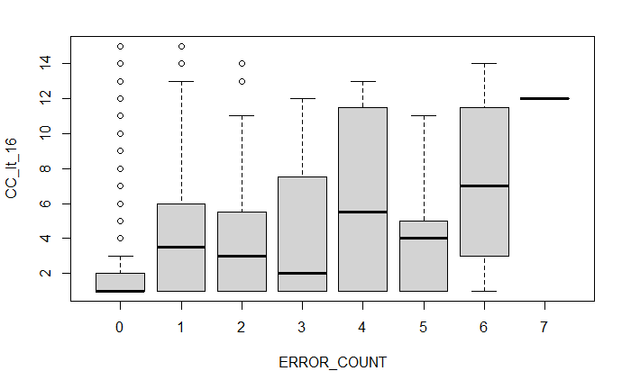

```r
 boxplot(CYCLOMATIC_COMPLEXITY~ERROR_COUNT, ylab="CC_lt_16",cc_restricted)
```

```r
summary(cc_restricted$CYCLOMATIC_COMPLEXITY)
```

```
   Min. 1st Qu.  Median    Mean 3rd Qu.    Max.
  1.000   1.000   1.000   2.406   3.000  15.000
```

```r
summary(cc_restricted$ERROR_COUNT)
```

```
   Min. 1st Qu.  Median    Mean 3rd Qu.    Max.
 0.0000  0.0000  0.0000  0.2269  0.0000  7.0000
```

for CC < 8

```r
cc_restricted <- data %>%
  filter(CYCLOMATIC_COMPLEXITY < 8)
```

Plot

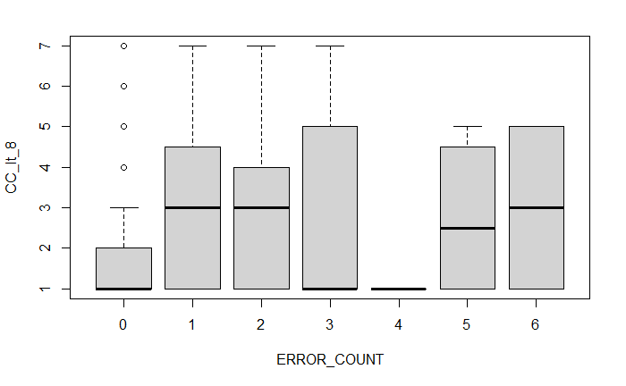

```r
 boxplot(CYCLOMATIC_COMPLEXITY~ERROR_COUNT, ylab="CC_lt_8",cc_restricted)
```

```r
summary(cc_restricted$CYCLOMATIC_COMPLEXITY)
```

```
   Min. 1st Qu.  Median    Mean 3rd Qu.    Max.
  1.000   1.000   1.000   1.872   2.000   7.000
```

```r
summary(cc_restricted$ERROR_COUNT)
```

```
   Min. 1st Qu.  Median    Mean 3rd Qu.    Max.
 0.0000  0.0000  0.0000  0.1883  0.0000  6.0000
```

for CC < 4

```r
cc_restricted <- data %>%
  filter(CYCLOMATIC_COMPLEXITY < 4)
```

Plot

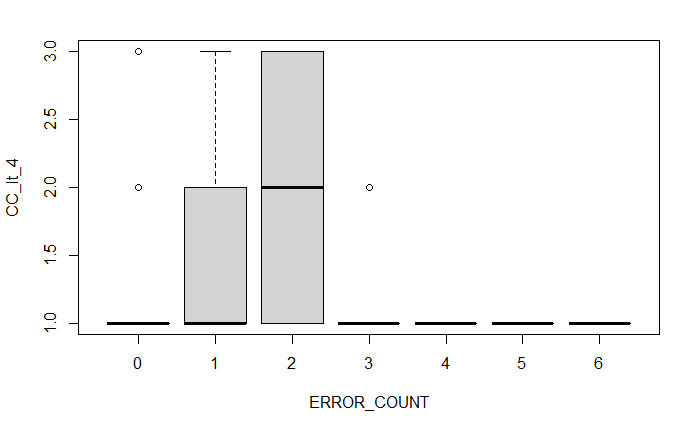

```r
 boxplot(CYCLOMATIC_COMPLEXITY~ERROR_COUNT, ylab="CC_lt_4",cc_restricted)
```

```r
summary(cc_restricted$CYCLOMATIC_COMPLEXITY)
```

```
   Min. 1st Qu.  Median    Mean 3rd Qu.    Max.
  1.000   1.000   1.000   1.353   2.000   3.000
```

```r
summary(cc_restricted$ERROR_COUNT)
```

```
   Min. 1st Qu.  Median    Mean 3rd Qu.    Max.
  0.000   0.000   0.000   0.141   0.000   6.000
```

for CC < 2

```r
cc_restricted <- data %>%
  filter(CYCLOMATIC_COMPLEXITY < 2)
```

Plot

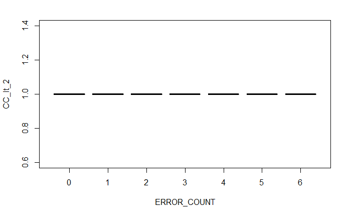

```r
 boxplot(CYCLOMATIC_COMPLEXITY~ERROR_COUNT, ylab="CC_lt_2",cc_restricted)
```

```r
summary(cc_restricted$CYCLOMATIC_COMPLEXITY)
```

```
   Min. 1st Qu.  Median    Mean 3rd Qu.    Max.
      1       1       1       1       1       1
```

```r
summary(cc_restricted$ERROR_COUNT)
```

```
   Min. 1st Qu.  Median    Mean 3rd Qu.    Max.
 0.0000  0.0000  0.0000  0.1166  0.0000  6.0000
```

### Result of Analysis

**From above analysis we can see the relation between Cyclomatic Complexity of module and and the error count in the same module.** **Above plots and the summary of the plots shows changing the error count on varying cyclomatic complexity.**

## Finding 2

### Relation of LOC_BLANK, LOC_EXECUTABLE, LOC_CODE_AND_COMMENT,LOC_COMMENT with ERROR_COUNT

Same procedure as finding_1.

Plotting Each variables with ERROR_COUNT Analysis of the summary

Sample Run

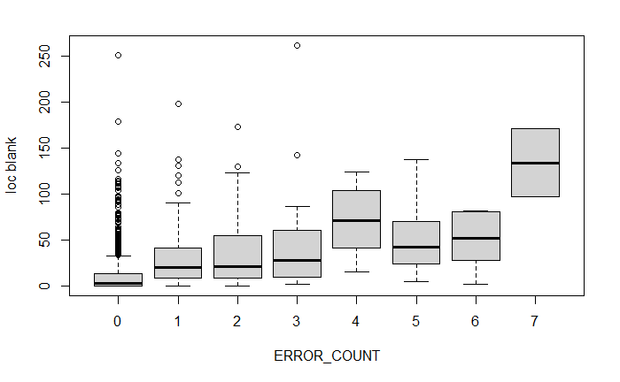

```r
result_1 <-boxplot(LOC_EXECUTABLE~ERROR_COUNT, ylab="loc blank",data)
```

```r
summary(data$LOC_EXECUTABLE)
```

```
   Min. 1st Qu.  Median    Mean 3rd Qu.    Max.
   0.00    0.00    5.00   14.54   17.00  262.00
```

```r
summary(data$ERROR_COUNT)
```

```
   Min. 1st Qu.  Median    Mean 3rd Qu.    Max.
 0.0000  0.0000  0.0000  0.2492  0.0000  7.0000
```

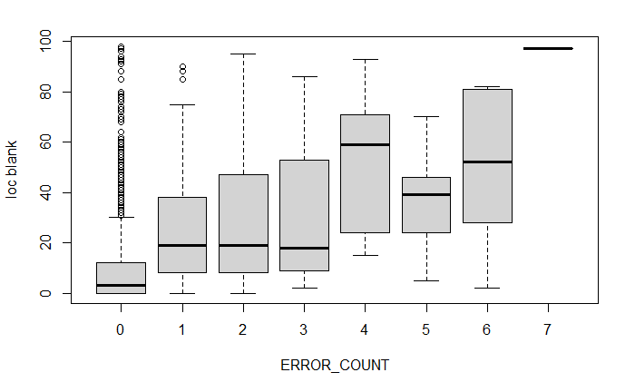

```r
data_1 <- data %>%
  filter(LOC_EXECUTABLE < 100)
result_1 <-boxplot(LOC_EXECUTABLE~ERROR_COUNT, ylab="loc blank",data_1)
```

```r
summary(data_1$LOC_EXECUTABLE)
```

```
   Min. 1st Qu.  Median    Mean 3rd Qu.    Max.
   0.00    0.00    5.00   12.67   16.00   98.00
```

```r
summary(data_1$ERROR_COUNT)
```

```
   Min. 1st Qu.  Median    Mean 3rd Qu.    Max.
 0.0000  0.0000  0.0000  0.2328  0.0000  7.0000
```

Similarly for rest of the variables, LOC_BLANK, LOC_CODE_AND_COMMENT,LOC_COMMENT.

# **Prediction**

REF: https://www.rdocumentation.org/packages/car/versions/3.0-8/topics/Predict

Linear Model

```r
model_lm <- lm(ERROR_COUNT~CYCLOMATIC_COMPLEXITY, data)

summary(model_lm)
```

```
Call:
lm(formula = ERROR_COUNT ~ CYCLOMATIC_COMPLEXITY, data = data)

Residuals:
    Min      1Q  Median      3Q     Max
-2.1519 -0.1979 -0.1368 -0.1368  6.1915

Coefficients:
                      Estimate Std. Error t value Pr(>|t|)
(Intercept)           0.075781   0.018484    4.10 4.29e-05 ***
CYCLOMATIC_COMPLEXITY 0.061061   0.003831   15.94  < 2e-16 ***
---
Signif. codes:  0 ‘***’ 0.001 ‘**’ 0.01 ‘*’ 0.05 ‘.’ 0.1 ‘ ’ 1

Residual standard error: 0.686 on 2105 degrees of freedom
Multiple R-squared:  0.1077,    Adjusted R-squared:  0.1073
F-statistic: 254.1 on 1 and 2105 DF,  p-value: < 2.2e-16
```

New predicted Values And summary

```r
data$pred<-predict(model_lm,newdata = data)# These are the predicted values
str(data$pred)
```

```
 Named num [1:2107] 0.137 0.137 0.137 0.137 0.137 ...
 - attr(*, "names")= chr [1:2107] "1" "2" "3" "4" ...
```

summary of predicted value

```r
summary(data$pred)
```

```
   Min. 1st Qu.  Median    Mean 3rd Qu.    Max.
 0.1368  0.1368  0.1368  0.2492  0.2590  2.8235
```

Install Package for Evaluation of the Model #“mae”: mean absolute error #“mse”: mean squared error, #“rmse”: root mean squared error

```r
library(DMwR)
regr.eval(data$CYCLOMATIC_COMPLEXITY,data$pred)
```

```
       mae        mse       rmse       mape
 2.5904129 20.1288017  4.4865133  0.8852149
```

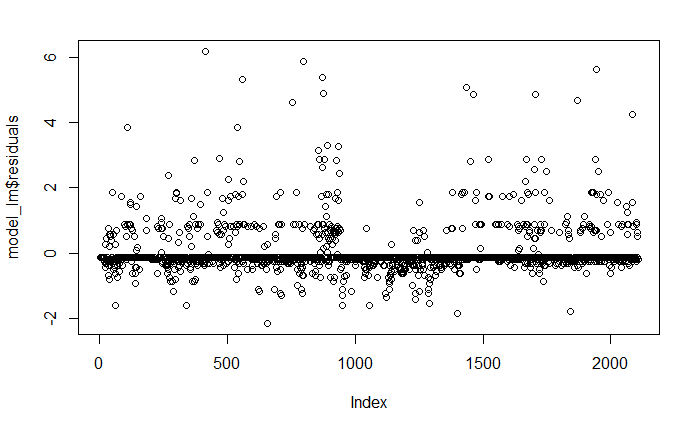

```r
plot(model_lm$residuals)
```

## Prediction on new value of CC

```r
predict(model_lm,newdata = data.frame(CYCLOMATIC_COMPLEXITY=c(5,30,45)))
```

```
        1         2         3
0.3810871 1.9076172 2.8235352
```

## Results

**Result of the prediction can be seen with less accuracy.** **With altering the parameters in the lm accuracy may be improved.**

## References

http://promise.site.uottawa.ca/SERepository/datasets-page.html